# Ointrodev

**Introduction: Octave and Jupyter**

Welcome to *Octave*, on HCC/Binder, through Jupyter.

*"Scientific Programming Language Octave is free software for numerical computations"*  
[www.gnu.org/software/octave](https://www.gnu.org/software/octave/)  
"The Jupyter Notebook is an open-source web application that allows you to create and share documents that contain live code,  
equations, visualizations and narrative text"  
[www.jupyter.org](https://jupyter.org/)

**Jupyter Notebook**  
Segregated into a kernel (execute code) and dashboard & editor (interface), Jupyter permits mixing real-time coding with interactive rich-text ouputs in self-contained *.ipynb(JSON)* documents (local or remote).  
Kernels include Julia, Python, R, MATLAB/Octave, etc.  
Interact with input cells (code, markdown, etc) that exhibit an order and mode - insert, edit, run.

`$ jupyter notebook`

**Octave**  
Starting *Octave* loads an interpreter and creates a workspace/environment to store values and perform commands.  
Interact with terminal directly or indirectly through scripts (*.m* extension).

```matlab
#Octave - load & open (terminal)
#module load octave
#octave
```

```matlab
%print info about Octave
ver()
```

```
----------------------------------------------------------------------
GNU Octave Version: 4.2.1
GNU Octave License: GNU General Public License
Operating System: Linux 2.6.32-754.17.1.el6.x86_64 #1 SMP Tue Jul 2 08:51:06 CDT 2019 x86_64
----------------------------------------------------------------------
no packages installed.
```

```matlab
%get (/change) current/working directory
pwd()
%cd('\home\')

%dir(pwd()); %RUN BELOW, INSERT NEW CELL ...
```

```matlab
dir(pwd())
```

**Calculations**  
Mathematical calculations - elements & arrays (/vectors).  
Example operators: `+`, `-`, `*`, `/`, `^`.

```matlab
(20+20)/5
```

```
ans =  8
```

```matlab
[1,2,3,4] .* [1,2,3,4]
```

```
ans =

    1    4    9   16
```

```matlab
sqrt(81); %built-in code (base functions)
```

**#Tip 1.** suppress output with ';' and interrupt interpreter with 'Ctrl-C'.

**Functions**  
Perform procedures - Input to Output with options/arguments (*round brackets*).  
With no defined arguments, functions when called will resort to default values found in documentation (help).

```matlab
%nested example (rand = generate random number)
disp(sort(rand([1, 10]),'ascend'))
```

```
 Columns 1 through 8:

   0.26419   0.39806   0.41374   0.46390   0.53482   0.62356   0.64295   0.66726

 Columns 9 and 10:

   0.69806   0.74288
```

```matlab
%check documentation (usage, arguments, details, examples, etc)
help sort
```

```
'sort' is a built-in function from the file libinterp/corefcn/data.cc

 -- [S, I] = sort (X)
 -- [S, I] = sort (X, DIM)
 -- [S, I] = sort (X, MODE)
 -- [S, I] = sort (X, DIM, MODE)
     Return a copy of X with the elements arranged in increasing order.

     For matrices, 'sort' orders the elements within columns

     For example:

          sort ([1, 2; 2, 3; 3, 1])
             =>  1  1
                 2  2
                 3  3

     If the optional argument DIM is given, then the matrix is sorted
     along the dimension defined by DIM.  The optional argument 'mode'
     defines the order in which the values will be sorted.  Valid values
     of 'mode' are "ascend" or "descend".

     The 'sort' function may also be used to produce a matrix containing
     the original row indices of the elements in the sorted matrix.  For
     example:

          [s, i] = sort ([1, 2; 2, 3; 3, 1])
            => s = 1  1
                   2  2
                   3  3
            => i = 1  3
                   2  1
                   3  2

     For equal elements, the indices are such that equal elements are
     listed in the order in which they appeared in the original list.

     Sorting of complex entries is done first by magnitude ('abs (Z)')
     and for any ties by phase angle ('angle (z)').  For example:

```

[output cut: 9 more lines]

```
     arrays of strings, in which case ASCII dictionary order (uppercase
     'A' precedes lowercase 'a') of the strings is used.

     The algorithm used in 'sort' is optimized for the sorting of
     partially ordered lists.

     See also: sortrows, issorted.

Additional help for built-in functions and operators is
available in the online version of the manual.  Use the command
'doc <topic>' to search the manual index.

Help and information about Octave is also available on the WWW
at http://www.octave.org and via the help@octave.org
mailing list.
```

```matlab
[S, I] = sort(rand([1, 10]),'ascend')
```

```
S =

 Columns 1 through 7:

   0.070673   0.083258   0.493424   0.537464   0.555542   0.574185   0.608628

 Columns 8 through 10:

   0.808570   0.949252   0.996867

I =

    4    6    3    1    7    8    5    9    2   10
```

```matlab
function [SE] = calculate_SE(x)
    %define function to calculate standard error (body - local env)
    SE = sqrt(var(x) / length(x));
endfunction

calculate_SE([10.4, 5.6, 3.1, 6.4, 21.7]) %run function
```

```
ans =  3.2819
```

**Assignment**  
Command `=` assigns and stores outputs/results as well as functions to memory (case-sensitive).  
Octave operates on named data structures, that is, sets of ordered entities.  
Example vectors: numeric (double, integer, complex), logical, character.

```matlab
x = [10.4, 5.6, 3.1, 6.4, 21.7]

class(x)
```

```
x =

   10.4000    5.6000    3.1000    6.4000   21.7000

ans = double
```

```matlab
%y = ['test'; 'control'; 'control'; 'control'; 'test'];
y = {'test', 'control', 'control', 'control', 'test'}

class(y)
```

```
y =
{
  [1,1] = test
  [1,2] = control
  [1,3] = control
  [1,4] = control
  [1,5] = test
}
ans = cell
```

**#Tip 3.** use tab for auto-completion & arrow keys for command history.

```matlab
%matrices - visualize toy example
X = rand([4, 5]);
%X = reshape(rand([1, 20]), 4, 5);

size(X)
X
```

```
ans =

   4   5

X =

   0.348236   0.760752   0.015786   0.929825   0.317086
   0.430236   0.770919   0.313245   0.878983   0.452834
   0.863609   0.686514   0.896878   0.327665   0.897334
   0.999835   0.087942   0.688789   0.577080   0.783822
```

**Indexing**  
Access parts of a dataset, rows then columns (*round brackets again*), starting with 1, can be coded multiple ways.  
Wildcard `:` generates a regular sequence from start to stop (by 1).  
Concatenate row-wise with `,` or column-wise with `;` (*square brackets*).

```matlab
X(2,4)
```

```
ans =  0.87898
```

```matlab
X'(2,4) %transpose (rows to columns, columns to rows)
```

```
ans =  0.087942
```

```matlab
X([2,4], 4) = [0,10]; %replace elements
X
```

```
X =

    0.34824    0.76075    0.01579    0.92983    0.31709
    0.43024    0.77092    0.31325    0.00000    0.45283
    0.86361    0.68651    0.89688    0.32766    0.89733
    0.99983    0.08794    0.68879   10.00000    0.78382
```

```matlab
X(1:3,2:3)

[X(1:3,2), X(1:3,3)] %concatenate columns (',')

[X(1,2:3); X(2,2:3); X(3,2:3)]  %concatenate rows (';')
```

```
ans =

   0.760752   0.015786
   0.770919   0.313245
   0.686514   0.896878

ans =

   0.760752   0.015786
   0.770919   0.313245
   0.686514   0.896878

ans =

   0.760752   0.015786
   0.770919   0.313245
   0.686514   0.896878
```

**#Tip 4.** 'end' is magic when indexing (last entry).

**Conditions**  
Checks that control the flow of actions/execution (if / else).  
Comparsion: lesser than (`<`), greater than (`>`), equal (`==`), different (`~=`).  
Logical/Boolean: AND (`&`) if both *true*, OR (`|`) if either *true*, NOT (`~`) converts *true* to *false*.

```matlab
X(X > 0.50) %output - free from dimensions
X
```

```
ans =

    0.86361
    0.99983
    0.76075
    0.77092
    0.68651
    0.89688
    0.68879
    0.92983
   10.00000
    0.89733
    0.78382

X =

    0.34824    0.76075    0.01579    0.92983    0.31709
    0.43024    0.77092    0.31325    0.00000    0.45283
    0.86361    0.68651    0.89688    0.32766    0.89733
    0.99983    0.08794    0.68879   10.00000    0.78382
```

```matlab
X(X >= 0.60 & X <= 0.70) %across whole matrix
X(1, X(1,:) >= 0.60 & X(1,:) <= 0.70) %only first row
```

```
ans =

   0.68651
   0.68879

ans = [](1x0)
```

```matlab
if (size(X,1) != 4);
    disp("check - dimensions don't match") %first check cond.1, TRUE do something
elseif (size(X,2) != 5);
    disp("check - dimensions don't match") %FALSE then try cond.2, TRUE now do something different
else
    disp("good - dimensions match") %FALSE again, do something else
end
```

```
good - dimensions match
```

```matlab
y(strcmp('test', y))
%strfind('test', y)
```

```
ans =
{
  [1,1] = test
  [1,2] = test
}
```

```matlab
%CHECK-IN POINT
%EXERCISE - create two separate 3D matrices, dimensions 3,4,5, of 60 random numbers between 1 and 100, and
%perform element-wise multiplication.

%EXERCISE - define new function, roundndivide, to take two numeric/double inputs (x1 and x2), rounds to nearest integers,
%divides integers, and returns logical output (TRUE/FALSE) if absolute of result is greater than 1.
```

```matlab
%initiate variable of NA (missing values) to fill during loop (preallocate - growing objects inefficient)
colMean = repmat(NA, [1, size(X,2)]);

for i = 1:size(X,2);
    %variable i in sequence start:end
    i
    colMean(i) = mean(X(:,i));
    %break;%continue
end

colMean
```

```
i =  1
i =  2
i =  3
i =  4
i =  5
colMean =

   0.66048   0.57653   0.47867   2.81437   0.61277
```

```matlab
colMean = arrayfun(@(col)mean(X(:,col)), 1:size(X,2)); %column by column
colMean

%mean(X,1)
```

```
colMean =

   0.66048   0.57653   0.47867   2.81437   0.61277
```

```matlab
rowSE = arrayfun(@(row)calculate_SE(X(row,:)), 1:size(X,1)); %row by row
rowSE
```

```
rowSE =

   0.16438   0.12422   0.10894   1.87808
```

**#Tip 5.** 'break' jumps out of loop & 'continue' skips to next cycle.

**Packages**  
Executable codes/functions developed by the community are organised and shared online in resposities - these can be retrieved/downloaded (source (compile) vs bundled (compressed) vs binary (pre-built)), structured into directories (libraries) and loaded into memory to use. Packages will often require other packages - dependencies.  
Repositories: Forge (official network), MATLAB (File Exchange), GitHub.  
Packages: `io`, `statistics`, `image`, `signal`.

```matlab
pkg list %print available/downloaded packages
%addpath('/home/riethoven/tpayne/octav')
```

```matlab
%pkg install -forge io
pkg load io

%pkg unload io
```

```matlab
%cells - visualize toy example
dat = [
        [{'sampleID'}, {'exp1'}, {'exp2'}, {'exp3'}, {'exp4'}];
        [{'groupID', 'control', 'control', 'test', 'test'}];
        [{'tp1'}, {10}, {12}, {11}, {11}]; %measurement @ timepoint-1
        [{'tp2'}, {20, 20, 38, 39}]; %measurement @ timepoint-2
        [{'tp3', 20, 20, 50, 52}]; %measurement @ timepoint-3
        ];

dat
```

```
dat =
{
  [1,1] = sampleID
  [2,1] = groupID
  [3,1] = tp1
  [4,1] = tp2
  [5,1] = tp3
  [1,2] = exp1
  [2,2] = control
  [3,2] =  10
  [4,2] =  20
  [5,2] =  20
  [1,3] = exp2
  [2,3] = control
  [3,3] =  12
  [4,3] =  20
  [5,3] =  20
  [1,4] = exp3
  [2,4] = test
  [3,4] =  11
  [4,4] =  38
  [5,4] =  50
  [1,5] = exp4
  [2,5] = test
  [3,5] =  11
  [4,5] =  39
  [5,5] =  52
}
```

```matlab
class(dat)
```

```
ans = cell
```

**Manipulation**  
Selecting and excluding variables and observations.  
Base functions exist also and again can be coded multiple ways.

```matlab
%unique(dat(2,:))

datTest = dat(:, strcmp(dat(2,:), 'test')==1);datTest
indexTest = find( strcmp(dat(2,:),'test') ==1);indexTest

datminusTest = dat;
datminusTest(indexTest,:) = [];%datminusTest
```

```
datTest =
{
  [1,1] = exp3
  [2,1] = test
  [3,1] =  11
  [4,1] =  38
  [5,1] =  50
  [1,2] = exp4
  [2,2] = test
  [3,2] =  11
  [4,2] =  39
  [5,2] =  52
}
indexTest =

   4   5
```

**Structures**  
Structures are data containers (fields) that group related data (*period*).  
Define structures with field (name) and value - scalar/nonscalar (s.f / s(n).f).

```matlab
%structure
df.X = x;
df.Y = y;
df.title = 'toy example';

df
```

[output not shown]

```matlab
%array of structures
df(2).X = x.^2;
df(2).Y = y;
df(2).title = 'squared example';

df
```

```
df =

  1x2 struct array containing the fields:

    X
    Y
    title
```

```matlab
%CHECK-IN POINT
%EXERCISE -
```

**Plotting**  
For visualizations *Octave* relies upon either GNUPLOT, FLTK or OpenGL. Plots (2D/3D) are created and controlled using high-level functions with pointers (graphic handles) for individual base object types (hierarchical) and associated properties - *figure*, *axes*, *line*, *text*, *patch*, *surface*, *text*, *image*, *light*. Values can be retrieved or altered with `get()` or `set()`, respectively.  
Examples: `scatter`, `hist`, `bar`, `pie`, `area`, `fill`, `contour`, `image`, `imagesc`.

```matlab
x = [0.5:0.5:10];
y = rand([1,20]);
```

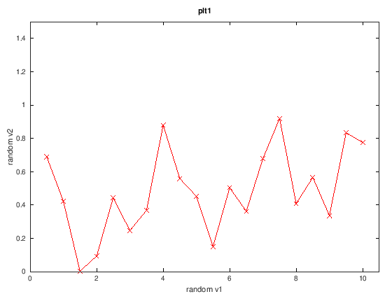

```matlab
%figure;
plot(x,y,'-rx');
set(gca,'XLim',[0, 10.5],'YLim',[0, 1.5]);
xlabel('random v1');ylabel('random v2');title('plt1');
```

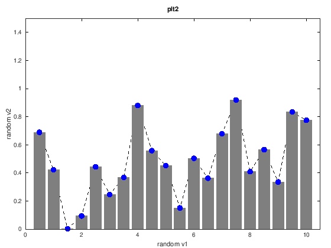

```matlab
%figure;
plot(x,y,'--k');
hold on;
bar(x,y,'facecolor',[0.5,0.5,0.5],'edgecolor',[0.5,0.5,0.5]);
hold on;
plot(x,y,'o','markeredgecolor',[0,0,1],'markerfacecolor',[0,0,1],'markersize',8);
set(gca,'XLim',[0, 10.5],'YLim',[0, 1.5]);
xlabel('random v1');ylabel('random v2');title('plt2');
```

```matlab
z = rand([1,20])*100;
```

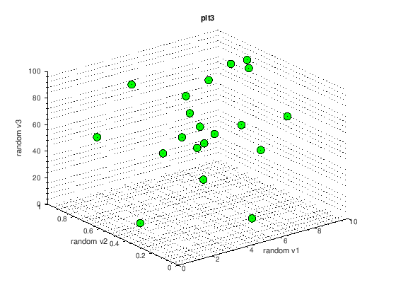

```matlab
%figure;
plot3(x(:), y(:), z(:), 'o','markeredgecolor',[0,0,0],'markerfacecolor',[0,1,0],'markersize',10)
grid minor on
xlabel('random v1');ylabel('random v2');zlabel('random v3');title('plt3');
```

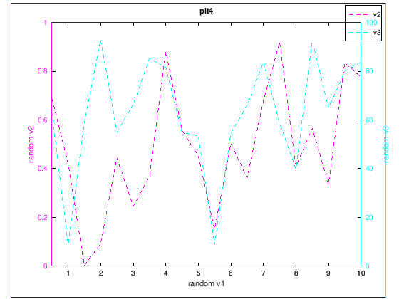

```matlab
%figure;
[ax, h1, h2] = plotyy(x,y,x,z);
set ([h1, h2], 'linestyle', '--');
set(h1, 'color', [1,0,1]);set(h2, 'color', [0 1 1]);
set(ax(1), 'Ycolor', [1,0,1]);set(ax(2), 'Ycolor', [0 1 1]);
xlabel('random v1');ylabel(ax(1), 'random v2');ylabel(ax(2), 'random v3');
legend('v2','v3') ;title('plt4');
```

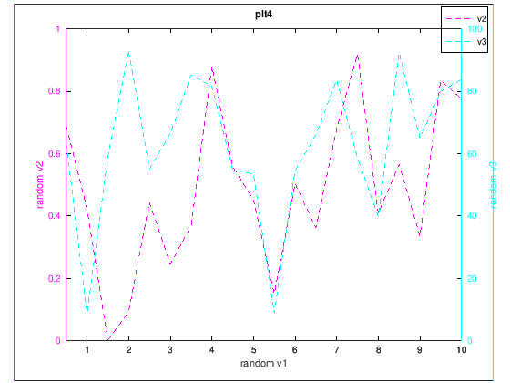

```matlab
%figure;
[ax, h1, h2] = plotyy(x,y,x,z);
set ([h1, h2], 'linestyle', '--');
set(h1, 'color', [1,0,1]);set(h2, 'color', [0 1 1]);
set(ax(1), 'Ycolor', [1,0,1]);set(ax(2), 'Ycolor', [0 1 1]);
xlabel('random v1');ylabel(ax(1), 'random v2');ylabel(ax(2), 'random v3');
legend('v2','v3') ;title('plt4');
print('-dpng','-r100','myPic.png')
```

```matlab
dList = { dir(pwd()).name };
dList( find( cellfun(@isempty, [strfind( dList, ".png")]) ==0))
```

```
ans =
{
  [1,1] = myPic.png
}
```

**#Tip 6.** new graphic objects become children of current axes, figure or root.

**Saving**  
Workspace objects can be saved as *.mat* files for logged records or future use.  
Results (data, figures, video) can be outputted as other files also.

```matlab
whos
```

[output not shown]

```matlab
clear ('height', 'width')
whos
```

[output not shown]

```matlab
%xlswrite()
%cell2csv()

fid = fopen("ExampleGGData.csv", "w");
for i = 1:size(dat,1);
  if i < 3;
  fprintf (fid, "%s, %s, %s, %s, %s \r\n", dat{i,:});
  else
  fprintf (fid, "%s, %.2f, %.2f, %.2f, %.2f \r\n", dat{i,:});
  end
end
fclose (fid);

%clear;clc
```

```matlab
dList = { dir(pwd())(:).name };
dList( find( cellfun(@isempty, [strfind( dList, ".csv")]) ==0))
```

[output not shown]

```matlab
save('data_05292019.mat');
%load('data_05292019.mat');
```

**Loading**  
Importing data into *Octave* from files (.csv/.txt) can range in complexity - multiple options/arguments.  
Examples: format (*"%s", "%d", "%f"*), separator/delimiter (*",", "\t", " "*), headerlines.

```matlab
%[num,txt,raw] = xlsread()
%csv2cell()

expectColNo = 5;

df = textread('ExampleGGData.csv', '%s' ,'delimiter' , ',');
df = reshape(df, expectColNo, (size(df,1)/expectColNo))';size(df)
df(1:3,1:4)
```

```
ans =

   5   5

ans =
{
  [1,1] = sampleID
  [2,1] = groupID
  [3,1] = tp1
  [1,2] = exp1
  [2,2] = control
  [3,2] = 10.00
  [1,3] = exp2
  [2,3] = control
  [3,3] = 12.00
  [1,4] = exp3
  [2,4] = test
  [3,4] = 11.00
}
```

```matlab
dat(1:3,1:4)
```

```
ans =
{
  [1,1] = sampleID
  [2,1] = groupID
  [3,1] = tp1
  [1,2] = exp1
  [2,2] = control
  [3,2] =  10
  [1,3] = exp2
  [2,3] = control
  [3,3] =  12
  [1,4] = exp3
  [2,4] = test
  [3,4] =  11
}
```

```matlab
%quit()
```

**Command Line**  
Within a terminal *Octave* can be interactive (open input) or not/batch (closed execution).

`$ octave Ocode.m`

*References*  
Software Carpentry: Our Lessons (https://software-carpentry.org/lessons)  
GNU Octave Beginner's Guide (http://calliope.dem.uniud.it/CLASS/ING-AMB/2018/GNU-Octave-for-beginners.pdf)